# Chap 10. Data visualization in practice

**Topic of this chapter**

1. faceting
2. time series plot
3. transformations
4. ridge plot

# **10.1 Case study : new insights on poverty**

- **Topic : Myth of poverty**
1. [New insights on Poverty](https://www.ted.com/talks/hans_rosling_reveals_new_insights_on_poverty?language=en)
2. [The best stats you’ve ever seen](https://www.ted.com/talks/hans_rosling_shows_the_best_stats_you_ve_ever_seen)
- **Main question**
1. Is it a fair characterization of today’s world to say it is divided into western rich nations and the developing world in Africa, Asia and Latin America?
2. Has income inequality across countries worsened during the last 40 years?

```r
str(gapminder)    #it's not tidyverse dataframe
```

```
'data.frame':   10545 obs. of  9 variables:
 $ country         : Factor w/ 185 levels "Albania","Algeria",..: 1 2 3 4 5 6 7 8 9 10 ...
 $ year            : int  1960 1960 1960 1960 1960 1960 1960 1960 1960 1960 ...
 $ infant_mortality: num  115.4 148.2 208 NA 59.9 ...
 $ life_expectancy : num  62.9 47.5 36 63 65.4 ...
 $ fertility       : num  6.19 7.65 7.32 4.43 3.11 4.55 4.82 3.45 2.7 5.57 ...
 $ population      : num  1636054 11124892 5270844 54681 20619075 ...
 $ gdp             : num  NA 1.38e+10 NA NA 1.08e+11 ...
 $ continent       : Factor w/ 5 levels "Africa","Americas",..: 4 1 1 2 2 3 2 5 4 3 ...
 $ region          : Factor w/ 22 levels "Australia and New Zealand",..: 19 11 10 2 15 21 2 1 22 21 ...
```

```r
gapminder %>% as.tibble()
```

```
`as.tibble()` is deprecated, use `as_tibble()` (but mind the new semantics).
```

| country | year | infant_mortality | life_expectancy | fertility | population | gdp | continent | region |
| --- | --- | --- | --- | --- | --- | --- | --- | --- |
| Albania | 1960 | 115.40 | 62.87 | 6.19 | 1636054 | NA | Europe | Southern Europe |
| Algeria | 1960 | 148.20 | 47.50 | 7.65 | 11124892 | 1.382815e+10 | Africa | Northern Africa |
| Angola | 1960 | 208.00 | 35.98 | 7.32 | 5270844 | NA | Africa | Middle Africa |
| Antigua and Barbuda | 1960 | NA | 62.97 | 4.43 | 54681 | NA | Americas | Caribbean |
| Argentina | 1960 | 59.87 | 65.39 | 3.11 | 20619075 | 1.083223e+11 | Americas | South America |
| Armenia | 1960 | NA | 66.86 | 4.55 | 1867396 | NA | Asia | Western Asia |
| Aruba | 1960 | NA | 65.66 | 4.82 | 54208 | NA | Americas | Caribbean |
| Australia | 1960 | 20.30 | 70.87 | 3.45 | 10292328 | 9.667786e+10 | Oceania | Australia and New Zealand |
| Austria | 1960 | 37.30 | 68.75 | 2.70 | 7065525 | 5.239270e+10 | Europe | Western Europe |
| Azerbaijan | 1960 | NA | 61.33 | 5.57 | 3897889 | NA | Asia | Western Asia |

[output cut: 990 more lines]

## 10.1.1 Hans Rosling’s quiz

1. Sri Lanka or Turkey
2. Poland or South Korea
3. Malaysia or Russia
4. Pakistan or Vietnam
5. Thailand or South Africa

> without data : prejudice that more developing countries will be in non-Europe

> with data

| country | infant_mortality | country | infant_mortality |
| --- | --- | --- | --- |
| Malaysia | 6.0 | South Korea | 2.9 |
| Pakistan | 65.8 | Russia | 8.2 |
| Poland | 4.5 | South Africa | 33.6 |
| Sri Lanka | 8.4 | Turkey | 11.6 |
| Thailand | 10.5 | Vietnam | 17.3 |

# **10.2 Scatterplots**

> Where the preconceived notion came from? Western world vs developing world
- Preconceived notion 1
1. Western world -> small family with long life span
2. developing world -> large family with short life span

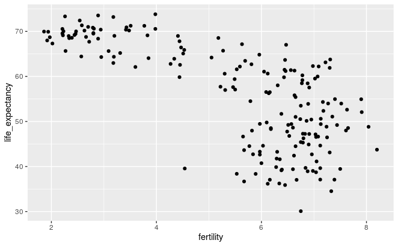

Most points fall into two distinct categories:

1. Life expectancy around 70 years and 3 or less children per family.
2. Life expectancy lower then 65 years and more than 5 children per family.

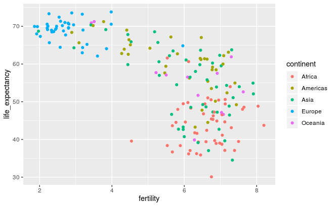

> In 1962 , preconceived notion looks real.

# **10.3 Faceting**

- seperating data to each group and plotting seperately

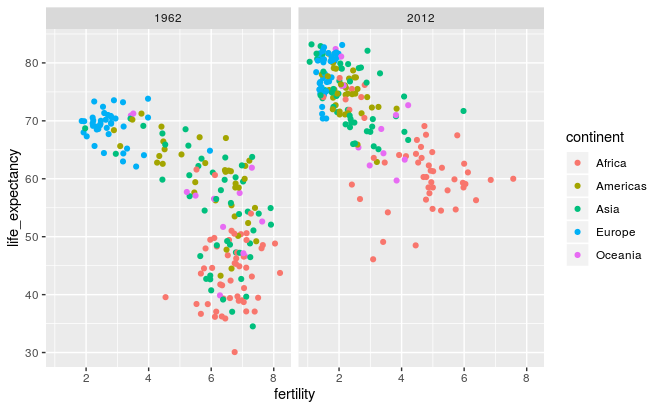

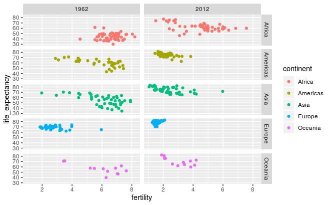

> `facet_grid(row~column)`

## 10.3.1 `facet_wrap`

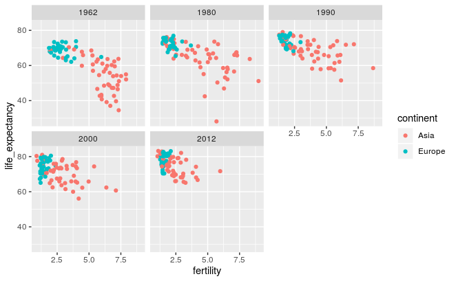

- compare with `facet_grid`
  - we can set the number of column and row in `facet_wrap`

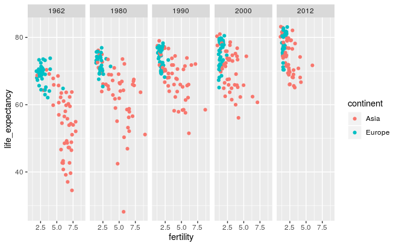

## 10.3.2 Fixed scales for better comparisons

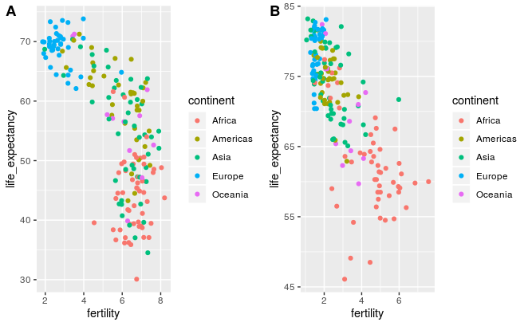

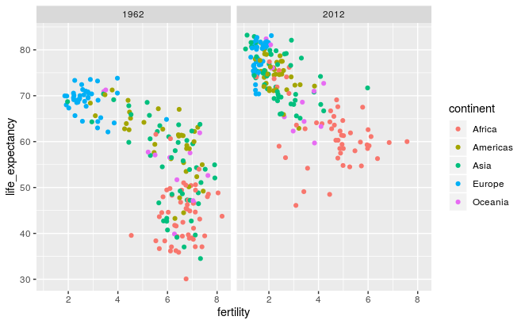

> when we use `ggarange`, the scale is not matched automatically `facet` fixed scales for better comparisions

# 10.4 Time series plots

- time series plots with one variable

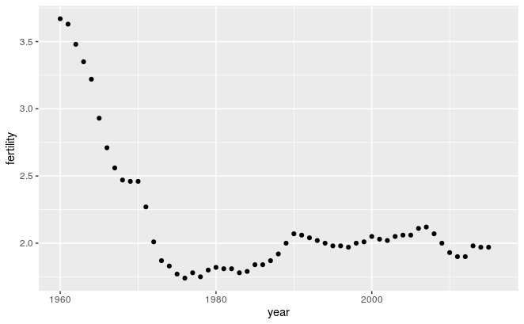

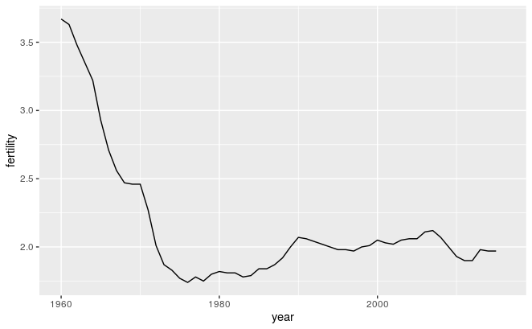

- time series plot with several variables

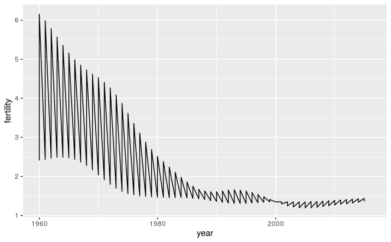

- we should make group in `aes`

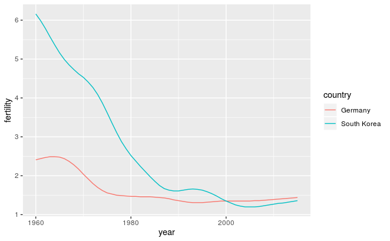

## 10.4.1 Labels instead of legends

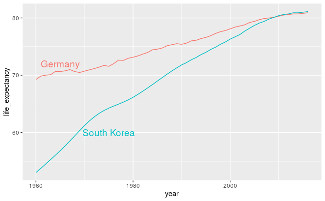

# 10.5 Data transformation

**Question 2 : Do poor countries have become poorer and rich countries become richer?**

## 10.5.1 Log transformation

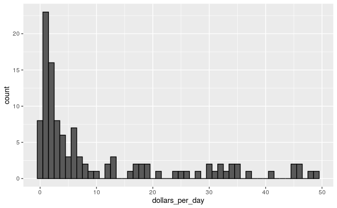

In this plot, we see that for the majority of countries, averages are below $10 a day. However, the majority of the x-axis is dedicated to the 35 countries with averages above $10. So the plot is not very informative about countries with values below $10 a day.

> less informative about countries with values below $10 a day

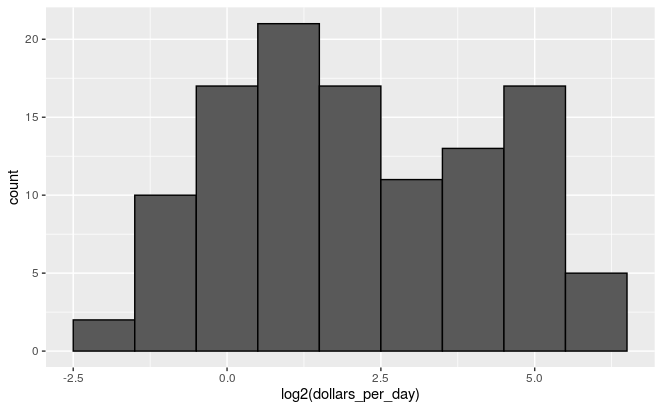

> *close-up* of the mid to lower income countries

> Log transformation provides an informative way to analyze one-side skewed data.

## 10.5.2 Which base?

> common base : 2, $e$, 10

> when using $e$, the scale is not intuitive or easy to interpret.

For an example in which base 10 makes more sense, consider population sizes. A log base 10 is preferable since the range for these is:

| min | max |
| --- | --- |
| 46075 | 808510713 |

Here is the histogram of the transformed values:

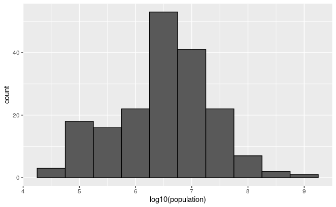

## 10.5.3 Transform the values or the scale?

> `scale_x_continuous` function shows the real value as a scale, instead of logging values.

> `scale_x_continuous(trans "log10")` = `scale_x_log10()`

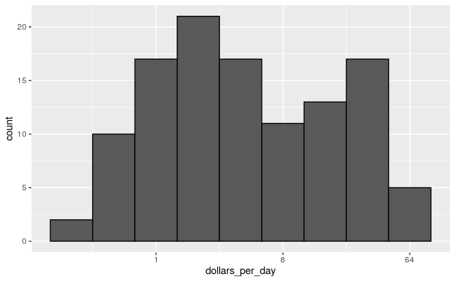

- argument of `scale_x_continuous(trans=)`
1. `sqrt` : square
2. `logit` : logistic transformation is useful when plotting proportions between 0 and 1.
3. `reverse` : reverse transformation is useful when we want smaller values to be on the right or on top.

#10.6 Visualizing multimodal distributions

- *modes* : *bumps* in the histogram. the value with the highest frequency
  - *local modes* : goes up and down again -> *multiple modes*
- normal distribution -> monomodality
- data above -> bimodality
  - This bimodality is consistent with a dichotomous world made up of countries with average incomes less than $8 (3 in the log 2 scale) a day and countries above that.

#10.7 Comparing multiple distribution with boxplots and ridge plots

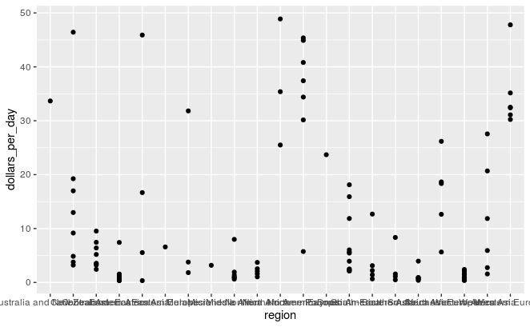

- We can rotate the axes with `coord_flip` or we can rotate the labels by changing the `theme` through `element_text`. The `hjust = 1` justifies the text so that it is next to the axis.

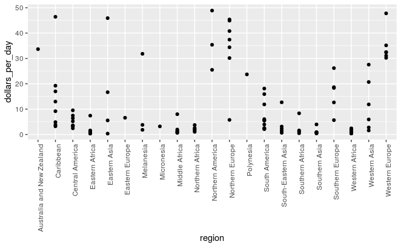

> By default, the regions are ordered alphabetically. But there is no practical reason! In general, **do not order alphabetically**

> Data exploration is often made easier if we order the strata by some **interpretable quantity**

```r
p <- gapminder %>%
  filter(year == past_year & !is.na(gdp)) %>%
  mutate(region = reorder(region, dollars_per_day, FUN = median)) %>% # `FUN` : orderign criteria / ordering by median value
  ggplot(aes(region, dollars_per_day)) +
  geom_point() +
  theme(axis.text.x = element_text(angle = 90, hjust =1))
p
```

- `reorder()`
- Q ) `mutate`는 열을 추가하는 함수. 그런데 `mutate(region = reorder())`은 원래 있던 열을 다른 열을 기준으로 재 정렬만 하는 과정.
  - `reorder`를 쓰더라도 dataframe 자체의 순서는 바뀌지 않는다? (section 3.5.4 다시보기)
  - 그럼에도 불구하고 plot에서는 순서가 바뀐다.

| region | dollars_per_day |
| --- | --- |
| Northern Africa | 3.7172265 |
| South America | 18.1207496 |
| Australia and New Zealand | 33.6671656 |
| Western Europe | 30.2348264 |
| Caribbean | 46.4254181 |
| Southern Asia | 0.7950843 |
| Caribbean | 16.9973307 |
| Western Europe | 31.0956941 |
| Central America | 3.2095300 |
| Western Africa | 0.7837057 |

[output cut: 103 more lines]

- we can see two clear groups with log transformation

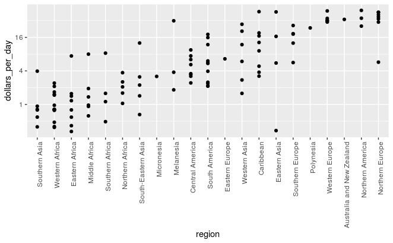

## 10.7.1 Boxplot

```r
gapminder <- gapminder %>%
  mutate(group = case_when(
    region %in% c("Western Europe", "Northern Europe","Southern Europe",
                    "Northern America", "Australia and New Zealand") ~ "West",
    region %in% c("Eastern Asia", "South-Eastern Asia") ~ "East Asia",
    region %in% c("Caribbean", "Central America", "South America") ~ " Latin America",
    continent == "Africa" & region != "North Africa" ~ " Sub-saharan Africa"
    TRUE ~ "Others"))
```

[output not shown]

We turn this `group` variable into a **factor** to control the order of the levels:

- box plot with outlier

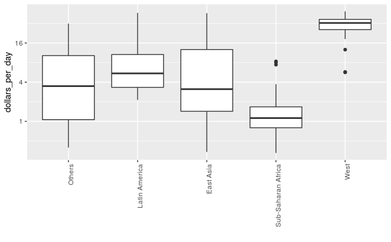

- Box plot with showing all data Boxplots have the limitation that by summarizing the data into five numbers, we might miss important characteristics of the data. One way to avoid this is by showing the data.

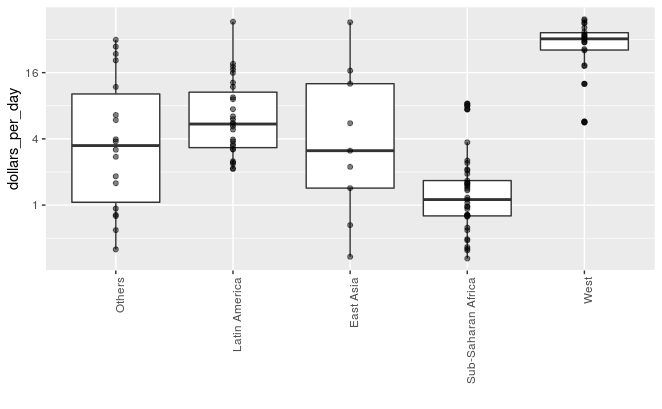

## 10.7.2 Ridge plots

- ridge plots : histogram with smooth densities
  - package **ggridges**

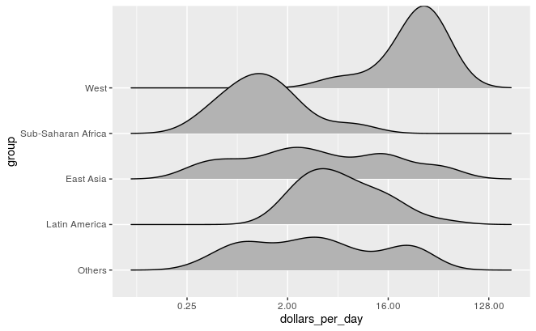

If the number of data points is small enough, we can add them to the ridge plot using the following code:

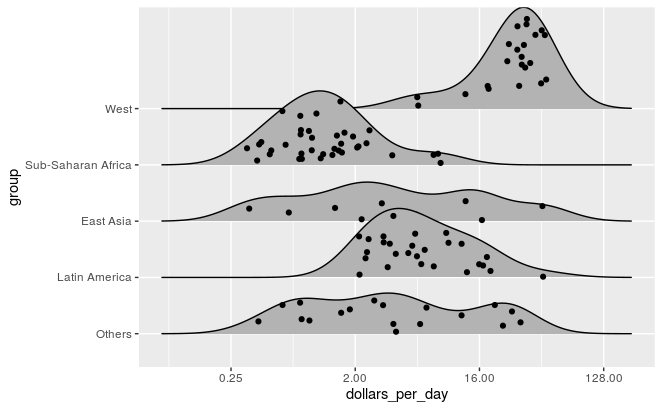

Make it more tidy, we can use *rug representation* :

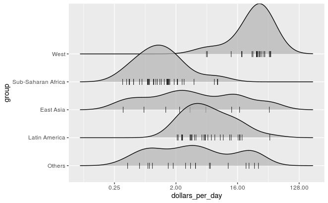

## 10.7.3 Example : 1970 versus 2010 income distributions

**Q) Data exploration clearly shows that in 1970 there was a “west versus the rest” dichotomy. But does this dichotomy persist?**

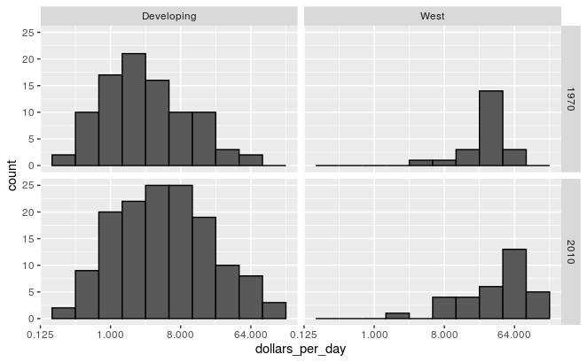

Before we interpret the findings of this plot, we notice that there are more countries represented in the 2010 histograms than in 1970: the total counts are larger. One reason for this is that several countries were founded after 1970. For example, the Soviet Union divided into several countries during the 1990s. Another reason is that data was available for more countries in 2010.

We remake the plots using only countries with data available for both years. In the data wrangling part of this book, we will learn **tidyverse** tools that permit us to write efficient code for this, but here we can use simple code using the `intersect` function:

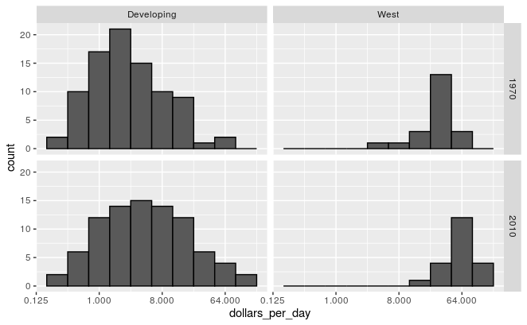

We now see that the rich countries have become a bit richer, but percentage-wise, the poor countries appear to have improved more. In particular, we see that the proportion of developing countries earning more than $16 a day increased substantially.

To see which specific regions improved the most, we can remake the boxplots we made above, but now adding the year 2010 and then using facet to compare the two years.

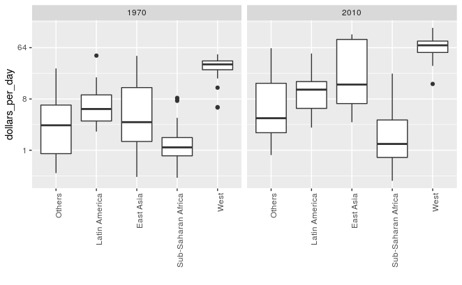

In general, comparisons are easier when data are plotted next to each other.

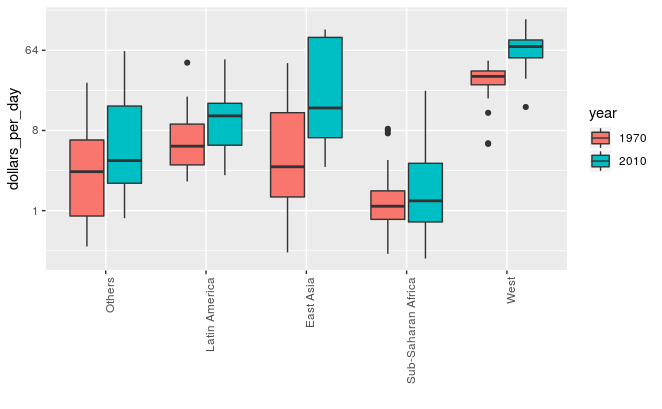

- 17. Then total income has been changed?
- 17. Is the gap continuously maintained?

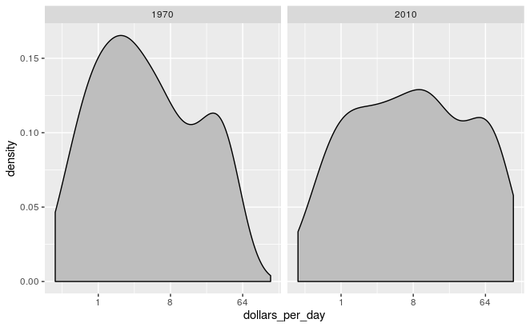

17. Then did poor countries become richer, or rich countries become poorer?

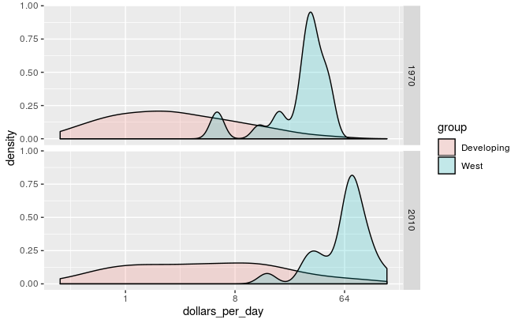